# Analyse_article_ADM_JB

Julie Boudrie M1 MFA

10/01/26

I-Introduction

L’article “Comparative analysis of microbial diversity across temperature gradients in hot springs from Yellowstone and Iceland », publié en 2020 dans le journal Frontiers in Microbiology” par Podar et al. https://doi.org/10.3389/fmicb.2020.01625) est l’une des rares études qui explore la diversité microbienne au sein et entre des sources géothermales éloignés (Islande et États-Unis). Les gradients de température qui se forment au niveau des sources chaudes conduisent à la formation de communautés microbiennes distinctes occupant leurs niches optimales et les sources chaudes sont donc idéales pour étudier l’adaptation et l’évolution des microorganismes sur une large gamme de températures. L’article vise donc à répondre à la question suivante : y a-t-il des similitudes ou des différences au niveau de la composition microbienne de sources chaudes éloignées ?

II-Matériels et méthodes

Les auteurs ont premièrement réalisé des échantillonnages au niveau des sites géothermales situés dans les villes de Flúðir (Vaðmálahver) et de Borgarfjörður (Hurðarbak) en Islande et du par américain de Yellowtone (Mirror Pool), suivie d’une analyse chimique de l’eau et d’extractions d’ADN (ZR Soil Microbe DNA Kit, Zymo Research). Ils ont ensuite séquencé des amplicons de la petite sous-unité de l’ARNr 16S (région V4 ciblée) et ont également utilisé des amorces modifiées spécifiques aux archées (515FCren, 515FNano…). L’analyse des amplicons de séquences a été réalisée en utilisant les outils Cutadapt et QIIME1 pour le prétraitement des séquences, VSEARCH et Deblur pour l’assemblage et le débruitage, MAFFT, QIIME2 et FastTree ainsi que plusieurs indices de diversité alpha et béta pour les analyses phylogénétiques et de diversité. Les analyses statistiques ont été réalisées avec les tests PERMANOVA, ADONIS, Spearman et ANOVA, et la classification des ASVs a été réalisées grâce à q2-feature-classifier et la base Silva 132. Enfin, d’autres analyses phylogénétiques ont été faites grâces aux outils BLASTN (comparaison de séquences) et PhyML (construction des arbres).

III-Résultats et discussion : utilisation du pipeline DADA2

[Getting ready]

```r
library(dada2)
packageVersion("dada2")
```

```
## [1] '1.28.0'
```

```r
path <- "~/Analyse_article_ADM_JB/DATA_article_JB"
list.files(path)
```

```
##  [1] "ena-file-download-read_run-PRJNA605860-fastq_ftp-20251002-1822.sh"
##  [2] "filtered"
##  [3] "SRR11066910_1.fastq"
##  [4] "SRR11066910_2.fastq"
##  [5] "SRR11066911_1.fastq"
##  [6] "SRR11066911_2.fastq"
##  [7] "SRR11066912_1.fastq"
##  [8] "SRR11066912_2.fastq"
##  [9] "SRR11066913_1.fastq"
## [10] "SRR11066913_2.fastq"
## [11] "SRR11066914_1.fastq"
## [12] "SRR11066914_2.fastq"
## [13] "SRR11066915_1.fastq"
## [14] "SRR11066915_2.fastq"
## [15] "SRR11066916_1.fastq"
```

[output cut: 53 more lines]

```r
fnFs <- sort(list.files(path, pattern="_1.fastq$", full.names = TRUE))
fnRs <- sort(list.files(path, pattern="_2.fastq$", full.names = TRUE))
sample.names <- sapply(strsplit(basename(fnFs), "_"), `[`, 1)
```

Apport de modifications par rapport au tutoriel DADA2, pour tenir compte de la structure du nom des échantillons, qui se terminent ici soit par “_1” soit par “_2” pour respectivement les reads forward et les reads reverse. Il y a pour chaque échantillon (commençant par SRR), deux fichiers FASTQ correspondant à tous les reads forward d’un côté et tous les reads reverse de l’autre pour le même échantillon. L’analyse des reads forward et reverse se fait en effet de manière séparée au début du tutoriel DADA2 (étapes filterAndTrim et learnErrors), ce qui peut ici différer de ce qu’ont fait les auteurs de l’article.

[Inspect read quality profile]

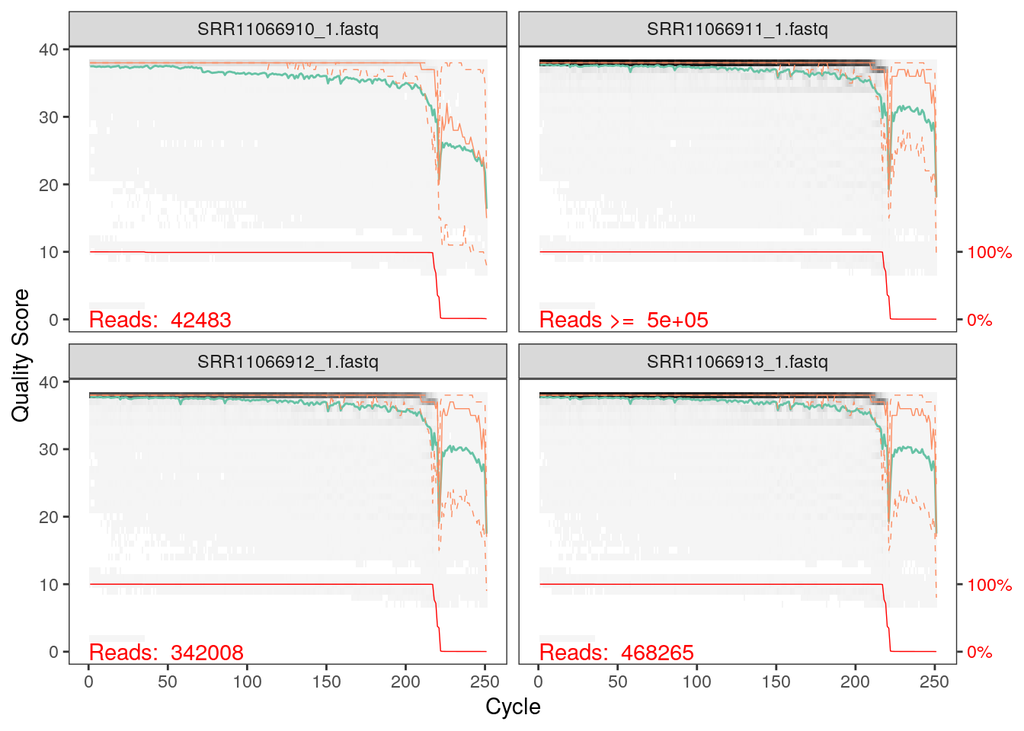

```r
plotQualityProfile(fnFs[1:4])
```

Les reads forward montrent une qualité stable et bonne (Q>30) jusqu’à environ 210-220 paires de bases (en regardant la ligne verte, correspondant au score de qualité moyen à chaque paire de base), et la distribution de ces scores (les quartiles, correspondant aux lignes oranges) reste assez stable jusqu’à cette longueur, avant de présenter des écarts considérables. La heatmap montre qu’une grande proportion de reads atteignent un score élevé jusqu’à 210-220 paires de base avant d’avoir des scores de qualité dissipés, générant “un nuage gris clair” passé cette longueur.

La proportion de reads qui atteignent les longueurs entre 210 et 250 paires de bases chute drastiquement : la ligne rouge reste à 100 % jusqu’à environ 220 paires de base avant de chuter, ce qui montre que même si la longueur initialement prévue est de 250 paires de base, peu de reads atteignent cette longueur. On remarque également qu’il y a de grandes différences dans le nombre de reads analysés en fonction de chaque échantillon.

Il s’agit de tendances, car quelques différences apparaissent en fonction des échantillons.

Pour la suite de l’analyse, nous avons choisi de tronquer les reads forward à 210 paires de base.

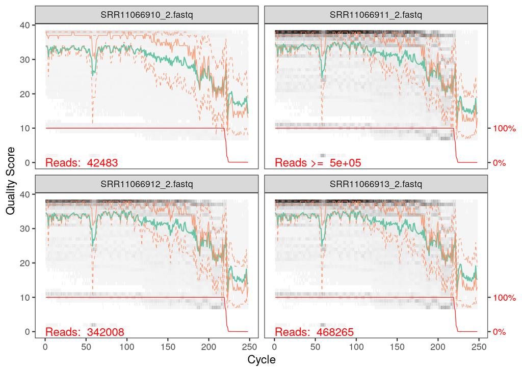

```r
plotQualityProfile(fnRs[1:4])
```

Les reads reverse présentent une qualité nettement moins stable et bonne que les reads forwards. Le score de qualité moyen chute sous le seuil de Q=30 assez tôt, aux alentours de 160 paires de bases, et la distribution des scores présente des variations importantes dès le début du séquençage. La heatmap confirme cela, car les reads présentent des scores de qualité dissipés, même si une bonne proportion des reads présentent une bonne qualité (Q>30) jusqu’à 160 paires de bases.

La proportion de reads qui atteignent les longueurs entre 210 et 250 paires de bases chute drastiquement : la ligne rouge reste à 100 % jusqu’à environ 220 paires de bases avant de tomber, ce qui montre que, comme pour les forwards, peu de reads atteignent la longueur maximale de 250 paires de bases. On remarque aussi les mêmes disparités dans le nombre de reads analysés en fonction de chaque échantillon.

Il s’agit de tendances, car quelques différences appariassent en fonction des échantillons.

Pour la suite de l’analyse, nous avons choisi de tronquer les reads reverse à 150 paires de bases.

[FilterandTrim]

```r
filtFs <- file.path(path, "filtered", paste0(sample.names, "_F_filt.fastq.gz"))
filtRs <- file.path(path, "filtered", paste0(sample.names, "_R_filt.fastq.gz"))
names(filtFs) <- sample.names
names(filtRs) <- sample.names
```

```r
out <- filterAndTrim(fnFs, filtFs, fnRs, filtRs, truncLen=c(210,150),
              maxN=0, maxEE=c(2,5), truncQ=2, rm.phix=TRUE,
              compress=TRUE, multithread=FALSE)
head(out)
```

```
##                     reads.in reads.out
## SRR11066910_1.fastq    42483     17814
## SRR11066911_1.fastq   771696    345081
## SRR11066912_1.fastq   342008    152453
## SRR11066913_1.fastq   468265    208484
## SRR11066914_1.fastq   354057    157424
## SRR11066915_1.fastq   252042    112807
```

Plusieurs tests de longueur de tronquature (et d’ajustement des paramètres) ont été effectués afin d’obtenir le meilleur compromis entre la longueur des séquences conservées et leur qualité. Une coupure à 210 pour les reads forward et à 150 pour les reads reverse reste selon nous le meilleur compromis. Le ratio obtenu entre le nombre de reads à l’origine et après filtrage n’est pas très élevé (environ 42 % en moyenne), même si la profondeur de séquençage diffère entre les échantillons. Ce dernier point peut représenter un biais à l’analyse des données, c’est pourquoi les auteurs ont réalisé une raréfaction du nombre de reads à 5 000 par échantillon. Nous réaliserons cette raréfaction aussi, notamment au moment de la réalisation de différents tests statistiques. Enfin, le paramètre maxEE (erreurs attendues) est ajusté à c(2,5) au lieu du standard c(2,2). Ce choix s’explique par mauvaise qualité des reads reverse observée sur les profils de qualité. En effet, en augmentant la tolérance d’erreur pour les séquences reverse à 5, on optimise le ratio de conservation des reads tout en laissant à l’algorithme DADA2 la capacité de corriger ces erreurs lors de l’étape ultérieure de débruitage.

[Learn the Error Rates]

```r
?learnErrors
```

```
## No documentation for 'learnErrors' in specified packages and libraries:
## you could try '??learnErrors'
```

le logiciel s’arrête dès qu’il franchit le seuil des 100 millions de bases (paramètre par défaut nbases = 1e+08)

```r
errF <- learnErrors(filtFs, multithread=FALSE)
```

```
## 108223080 total bases in 515348 reads from 3 samples will be used for learning the error rates.
```

La quantité de données fournie par les reads forward est suffisante pour poursuivre la suite de l’analyse (nombre de bases supérieur à cent millions), c’est-à-dire construire un modèle de taux d’erreur robuste.

```r
errR <- learnErrors(filtRs, multithread=FALSE)
```

```
## 108574800 total bases in 723832 reads from 4 samples will be used for learning the error rates.
```

La quantité de données fournie par les reads reverse est suffisante pour poursuivre la suite de l’analyse (nombre de bases supérieur à cent millions), c’est-à-dire construire un modèle de taux d’erreur robuste.

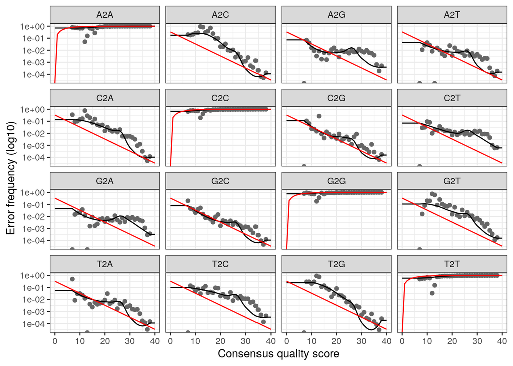

```r
plotErrors(errF, nominalQ=TRUE)
```

La visualisation des taux d’erreur (plotErrors) confirme que le modèle d’apprentissage est valide. Les taux d’erreur estimés (ligne noire) correspondent bien aux taux observés (points), et l’on remarque qu’ils suivent globalement la tendance théorique (ligne rouge) attendue pour les scores de qualité. Les taux d’erreur diminuent avec l’augmentation de la qualité, comme prévu. Nous pouvons donc poursuivre l’analyse.

[Sample Inference]

```r
dadaFs <- dada(filtFs, err=errF, multithread=FALSE)
```

```
## Sample 1 - 17814 reads in 2565 unique sequences.
## Sample 2 - 345081 reads in 22992 unique sequences.
## Sample 3 - 152453 reads in 11686 unique sequences.
## Sample 4 - 208484 reads in 15266 unique sequences.
## Sample 5 - 157424 reads in 12730 unique sequences.
## Sample 6 - 112807 reads in 11706 unique sequences.
## Sample 7 - 86164 reads in 10883 unique sequences.
## Sample 8 - 341690 reads in 23567 unique sequences.
## Sample 9 - 204081 reads in 14804 unique sequences.
## Sample 10 - 139792 reads in 11579 unique sequences.
## Sample 11 - 59026 reads in 5844 unique sequences.
## Sample 12 - 73846 reads in 6246 unique sequences.
## Sample 13 - 232422 reads in 18106 unique sequences.
## Sample 14 - 203791 reads in 13077 unique sequences.
## Sample 15 - 111270 reads in 14442 unique sequences.
## Sample 16 - 135918 reads in 17472 unique sequences.
## Sample 17 - 75762 reads in 9896 unique sequences.
## Sample 18 - 92159 reads in 7166 unique sequences.
## Sample 19 - 267817 reads in 24549 unique sequences.
## Sample 20 - 469455 reads in 32479 unique sequences.
## Sample 21 - 193205 reads in 14911 unique sequences.
## Sample 22 - 157736 reads in 14605 unique sequences.
## Sample 23 - 409462 reads in 30132 unique sequences.
## Sample 24 - 8438 reads in 1065 unique sequences.
## Sample 25 - 15456 reads in 1660 unique sequences.
## Sample 26 - 11077 reads in 1904 unique sequences.
## Sample 27 - 112558 reads in 12362 unique sequences.
## Sample 28 - 76139 reads in 7684 unique sequences.
## Sample 29 - 116582 reads in 13919 unique sequences.
## Sample 30 - 177845 reads in 14455 unique sequences.
## Sample 31 - 28750 reads in 3418 unique sequences.
## Sample 32 - 174008 reads in 13897 unique sequences.
## Sample 33 - 51931 reads in 5097 unique sequences.
```

```r
dadaRs <- dada(filtRs, err=errR, multithread=FALSE)
```

```
## Sample 1 - 17814 reads in 8666 unique sequences.
## Sample 2 - 345081 reads in 123091 unique sequences.
## Sample 3 - 152453 reads in 56360 unique sequences.
## Sample 4 - 208484 reads in 76765 unique sequences.
## Sample 5 - 157424 reads in 59550 unique sequences.
## Sample 6 - 112807 reads in 45722 unique sequences.
## Sample 7 - 86164 reads in 31582 unique sequences.
## Sample 8 - 341690 reads in 112198 unique sequences.
## Sample 9 - 204081 reads in 61464 unique sequences.
## Sample 10 - 139792 reads in 53475 unique sequences.
## Sample 11 - 59026 reads in 22674 unique sequences.
## Sample 12 - 73846 reads in 31715 unique sequences.
## Sample 13 - 232422 reads in 72967 unique sequences.
## Sample 14 - 203791 reads in 63408 unique sequences.
## Sample 15 - 111270 reads in 41197 unique sequences.
## Sample 16 - 135918 reads in 48911 unique sequences.
## Sample 17 - 75762 reads in 28108 unique sequences.
## Sample 18 - 92159 reads in 35579 unique sequences.
## Sample 19 - 267817 reads in 81263 unique sequences.
## Sample 20 - 469455 reads in 128257 unique sequences.
## Sample 21 - 193205 reads in 69641 unique sequences.
## Sample 22 - 157736 reads in 25185 unique sequences.
## Sample 23 - 409462 reads in 59268 unique sequences.
## Sample 24 - 8438 reads in 1502 unique sequences.
## Sample 25 - 15456 reads in 2400 unique sequences.
## Sample 26 - 11077 reads in 5642 unique sequences.
## Sample 27 - 112558 reads in 46159 unique sequences.
## Sample 28 - 76139 reads in 31626 unique sequences.
## Sample 29 - 116582 reads in 48966 unique sequences.
## Sample 30 - 177845 reads in 65567 unique sequences.
## Sample 31 - 28750 reads in 12483 unique sequences.
## Sample 32 - 174008 reads in 64137 unique sequences.
## Sample 33 - 51931 reads in 20350 unique sequences.
```

L’étape de débruitage montre une différence nette entre les reads forward et reverse, notamment au niveau du nombre de séquences uniques. En effet, bien que le nombre total de reads soit identique par échantillon, le nombre de séquences uniques est beaucoup plus élevé pour les reads reverse (par exemple : 123 091 contre 22 992 pour l’échantillon 2). Ce résultat est cohérent avec les analyses menées précédemment, qui ont montré une qualité moindre des reads reverse : la présence d’une plus grande quantité d’erreurs génère une diversité artificielle.

```r
dadaFs[[1]]
```

```
## dada-class: object describing DADA2 denoising results
## 114 sequence variants were inferred from 2565 input unique sequences.
## Key parameters: OMEGA_A = 1e-40, OMEGA_C = 1e-40, BAND_SIZE = 16
```

L’observation des résultats pour les reads forward du premier échantillon, via l’objet dadaFs[[1]], confirme l’efficacité de l’algorithme. En effet, 114 variants de séquences (ASV) ont été identifiés à partir des 2 565 séquences uniques initiales. Cela montre que l’algorithme a réussi à filtrer le bruit de fond pour ne conserver que les séquences biologiquement significatives.

```r
dadaRs[[1]]
```

```
## dada-class: object describing DADA2 denoising results
## 74 sequence variants were inferred from 8666 input unique sequences.
## Key parameters: OMEGA_A = 1e-40, OMEGA_C = 1e-40, BAND_SIZE = 16
```

L’observation des résultats pour les reads reverse du premier échantillon via l’objet dadaRs[[1]] confirme l’efficacité de l’algorithme. En effet, 74 variants de séquences (ASV) ont été identifiés à partir des 8 666 séquences uniques initiales. Cela montre que l’algorithme a réussi à filtrer le bruit de fond pour ne conserver que les séquences biologiquement significatives malgré un grand nombre de séquences uniques artificielles.

[Merge paired reads]

```r
mergers <- mergePairs(dadaFs, filtFs, dadaRs, filtRs, verbose=TRUE)

head(mergers[[1]])
```

```
##                                                                                                                                                                                                                                                        sequence
## 1 TACCCGCTCCGCGAGTGGTGAGGACTATTACTGGGCTTAAAGCGTCCGTAGCCGGCCCGG…
## 2 TACGTAGGGGCCGAGCGTTACCCGGATTTACTGGGCGTAAAGTGCGCGTAGGCGGGGCTC…
## 3 GACAGAGGTGGCGAGCGTTACCCGGATTCACTGGGCGTAAAGGGTGCGTAGGTGGTCGCG…
## 4 TACGTAGGGGGCGAGCGTTGCCCGAATTTACTGGGCGTAAAGCGCACGTAGGCGGCTCCG…
## 5 TACGGAGGGCGCGAGCGTTACCCGGATTTACTGGGCGTAAAGGGCGTGTAGGCGGCCTGG…
## 6 GACGTAGGGGGCGAGCGTTGCCCGGATTTACTGGGCGTAAAGCGGGTGTAGGCGGCCGGG…
##   abundance forward reverse nmatch nmismatch nindel prefer accept
## 1      2080       2       1    107         0      0      1   TRUE
## 2      1133       4       3    107         0      0      1   TRUE
## 3      1064       3       5    107         0      0      1   TRUE
## 4       969       5       4    107         0      0      1   TRUE
## 5       662       1       8    107         0      0      1   TRUE
## 6       639       9       9    107         0      0      1   TRUE
```

[Construct sequence table]

```r
seqtab <- makeSequenceTable(mergers)
dim(seqtab)
```

```
## [1]   33 5662
```

Le chiffre 33 correspondant au nombre d’échantillons, confirme qu’aucun échantillon n’a été perdu depuis le début et le chiffre 5 662 correspond au nombre total de variants de séquences (ASV) identifiées sur l’ensemble de notre analyse via DADA2.

```r
table(nchar(getSequences(seqtab)))
```

```
##
##  210  218  223  232  245  247  248  249  250  251  252  253  254  255  256  257
##    3    1    1    2    1    2    1    2   10    7  165 4601  318  115    1    6
##  258  263  268  269  270  271  272  273  274  275  276  277  278  279  280  281
##    1    1    1    2   14   12    5    3    9    4    6    7   14   27   22   52
##  282  283  284  285  286  287  288  289  290  292  293  295  296  298  299  302
##   49   59   34   41   15    6   11    5    3    7    1    3    2    1    1    1
##  305  316  333  335  345  346  347
##    1    1    1    1    1    1    1
```

La distribution de la longueur des séquences fusionnées, obtenue via la fonction nchar, montre une importante homogénéité. En effet, la grande majorité des variants (ASV) présente une taille comprise entre 252 et 254 pb, avec un pic central à 253 pb. Cette distribution est tout à fait conforme à la taille attendue pour la région V4 ciblée (250-254 paires de bases), ce qui confirme la spécificité de l’amplification PCR et la qualité de la fusion des reads.

[Remove chimeras]

```r
seqtab.nochim <- removeBimeraDenovo(seqtab, method="consensus", multithread=FALSE, verbose=TRUE)
dim(seqtab.nochim)
```

```
## [1]   33 3153
```

```r
sum(seqtab.nochim)/sum(seqtab)
```

```
## [1] 0.9718992
```

L’étape de suppression des séquences chimériques, réalisée avec la fonction removeBimeraDenovo, a permis d’identifier 2 509 chimères parmi les 5 662 séquences initiales. La table finale se compose donc de 3 153 variants de séquences (ASV) sur l’ensemble des 33 échantillons. Le nombre d’ASV a diminué d’environ 44 %, ce qui est élevé, mais nécessaire pour éliminer les artefacts générés par la PCR. Cependant, le calcul du ratio montre que 97,2 % des reads totaux sont conservés, ce qui prouve que ces chimères ne représentaient qu’une partie négligeable de l’abondance totale. Cela assure une plus grande fiabilité des analyses taxonomiques ultérieures.

[Track reads through the pipeline]

```r
getN <- function(x) sum(getUniques(x))
track <- cbind(out, sapply(dadaFs, getN), sapply(dadaRs, getN), sapply(mergers, getN), rowSums(seqtab.nochim))

colnames(track) <- c("input", "filtered", "denoisedF", "denoisedR", "merged", "nonchim")
rownames(track) <- sample.names
head(track)
```

```
##              input filtered denoisedF denoisedR merged nonchim
## SRR11066910  42483    17814     17670     17585  17186   16380
## SRR11066911 771696   345081    343916    343562 338563  322767
## SRR11066912 342008   152453    152029    151649 149898  144879
## SRR11066913 468265   208484    207912    207386 204261  196533
## SRR11066914 354057   157424    156881    156801 154287  150845
## SRR11066915 252042   112807    112167    112059 109732  106609
```

Le suivi des séquences, via l’objet track, montre une perte importante lors du filtrage initial, où environ la moitié des reads ont été écartés de l’analyse. Néanmoins, la suite du pipeline affiche une excellente conservation des données : les étapes de débruitage et de fusion n’apportent qu’une diminution minime du nombre de séquences. Enfin, la faible différence entre les colonnes merged et nonchim confirme que les chimères ne représentaient qu’une partie minime de l’abondance totale.

```r
sum(track[,"nonchim"])
```

```
## [1] 4751249
```

```r
ncol(seqtab.nochim)
```

```
## [1] 3153
```

La robustesse de ces données, combinée à l’utilisation du pipeline DADA2 à la place de l’approche QIIME1/Deblur des auteurs, explique la détection de 3 153 ASVs, soit une résolution de la diversité près de deux fois supérieure aux 1 729 ASVs rapportés par les auteurs. Les résultats sont également dus au fait que DADA2 s’affranchit des limites du modèle d’erreur statique de Deblur grâce à sa capacité à modéliser les erreurs spécifiquement pour chaque run, permettant de capturer une micro-diversité et une “biosphère rare” auparavant fusionnées ou ignorées.

Pour conclure sur cette partie, cette profondeur de séquençage optimisée permet de garantir une représentation de la diversité microbienne au sein des échantillons.

[Assign taxonomy]

```r
taxa <- assignTaxonomy(seqtab.nochim,"~/SILVA/silva_nr_v132_train_set(1).fa.gz", multithread=FALSE)
```

```r
taxa.print <- taxa
rownames(taxa.print) <- NULL
head(taxa.print)
```

```
##      Kingdom    Phylum          Class              Order
## [1,] "Bacteria" "Chloroflexi"   "Chloroflexia"     "Chloroflexales"
## [2,] "Bacteria" "Chloroflexi"   "Chloroflexia"     "Chloroflexales"
## [3,] "Archaea"  "Crenarchaeota" "Thermoprotei"     "Thermoproteales"
## [4,] "Bacteria" "Bacteroidetes" "Bacteroidia"      "Chitinophagales"
## [5,] "Archaea"  "Crenarchaeota" "Thermoprotei"     "Desulfurococcales"
## [6,] "Bacteria" "Cyanobacteria" "Oxyphotobacteria" "Nostocales"
##      Family             Genus
## [1,] "Roseiflexaceae"   "Roseiflexus"
## [2,] "Chloroflexaceae"  "Chloroflexus"
## [3,] "Thermoproteaceae" "Pyrobaculum"
## [4,] "Saprospiraceae"   NA
## [5,] NA                 NA
## [6,] "Nostocaceae"      "Chlorogloeopsis_PCC-7518"
```

L’assignassion taxonomique a été réalisée en utilisant la même base de donnée que l’article de référence (Silva v132) pour bien pouvoir comparer les résultats obtenus grâce à notre analyse. Ces premiers résultats montrent une diversité variée comprenant à la fois des bactéries (Chloroflexi, Bacteroidetes) et des archées (Crenarchaeota). On observe également la présence de NA pour certains taxons au niveau du genre et/ou de la famille : cela indique que ces séquences n’ont pas de correspondance suffisamment proche avec la base de données pour être classées avec fiabilité à ces rangs.

[Bonus: Handoff to phyloseq]

```r
library(phyloseq); packageVersion("phyloseq")
```

```
## [1] '1.44.0'
```

```r
# --- PRÉPARATION DE L'OBJET PHYLOSEQ CENTRAL ---
library(readxl)
library(phyloseq)

# 1. Chargement des métadonnées directement depuis Excel
metadata <- read_excel("~/meta.xlsx")
metadata <- as.data.frame(metadata)
# Correction : ciblage de la colonne "Sample ID" pour correspondre à seqtab
rownames(metadata) <- trimws(metadata$`Sample ID`)

# 2. Création de l'objet Phyloseq Maître (ps)
# seqtab (ASVs) et taxa (Taxonomie Silva 132) viennent de notre amont DADA2
ps <- phyloseq(otu_table(seqtab, taxa_are_rows=FALSE),
               sample_data(metadata),
               tax_table(taxa))
ps
```

```
## phyloseq-class experiment-level object
## otu_table()   OTU Table:         [ 3153 taxa and 33 samples ]
## sample_data() Sample Data:       [ 33 samples by 8 sample variables ]
## tax_table()   Taxonomy Table:    [ 3153 taxa by 6 taxonomic ranks ]
```

```r
# Nettoyage des noms de colonnes pour R
metadata <- data.frame(sample_data(ps))
colnames(metadata)[colnames(metadata) == "Temperature..oC"] <- "Temp_Num"

# Création des groupes de 5°C (40, 45, 50... 100)
metadata$Temp_Group <- cut(metadata$Temp_Num,
                           breaks = seq(35, 100, by = 5),
                           labels = seq(40, 100, by = 5))

sample_data(ps) <- metadata

# Raréfaction à 5000 (obligatoire selon l'article)
ps_rare <- rarefy_even_depth(ps, sample.size = 5000, rngseed = 123)
```

Il est important de noter que la raréfaction introduit un biais, puisqu’elle masque une partie de la diversité présente au sein des échantillons. En effet, les séquences correspondant aux taxons les plus abondants ont statistiquement plus de chances d’être tirées au sort, contrairement aux espèces rares lors du sous-échantillonnage aléatoire. Cette méthode permet néanmoins de corriger les différences de profondeur de séquençage entre les échantillons pour réaliser les différents tests statistiques et la comparaison des indices de diversité.

```r
# On utilise ps_rare (créé précédemment avec rarefy_even_depth)
alpha_rare <- estimate_richness(ps_rare, measures = "Observed")

# On fusionne avec les métadonnées de ps_rare
df_rare <- cbind(alpha_rare, as.data.frame(sample_data(ps_rare)))
```

```r
library(dplyr)
cv_stats_rare <- df_rare %>%
  filter(Thermal.Feature == "MirrorPool") %>%
  rename(Temp_Val = Temp_Num) %>% # Utilise le nom nettoyé dans ta raréfaction
  group_by(Thermal.Feature, Temp_Val) %>%
  summarise(
    mean_obs = mean(Observed),
    sd_obs = sd(Observed),
    cv_perc = (sd_obs / mean_obs) * 100,
    n = n(),
    .groups = 'drop'
  ) %>%
  filter(n > 1)

print(cv_stats_rare)
```

```
## # A tibble: 6 × 6
##   Thermal.Feature Temp_Val mean_obs sd_obs cv_perc     n
##   <chr>              <dbl>    <dbl>  <dbl>   <dbl> <int>
## 1 MirrorPool          52       112   26.1    23.3      3
## 2 MirrorPool          58.6     135    8       5.93     3
## 3 MirrorPool          65.5     127.  21.9    17.2      3
## 4 MirrorPool          69       113   24.9    22.0      3
## 5 MirrorPool          72.5     139.   5.69    4.08     3
## 6 MirrorPool          78       113    2.83    2.50     2
```

L’analyse de la richesse observée et de sa variabilité entre les réplicats de terrain par température révèle quelques différences avec l’étude de Podar et al. En effet, tandis que les auteurs rapportent une variabilité limitée, avec des coefficients de variation compris entre 0,2 % et 12 %, mon analyse à partir de DADA2 et après raréfaction indique une hétérogénéité supérieure entre réplicats, plusieurs points affichant un coefficient de variation dépassant les 20 %, avec un maximum de 23,27 % à 52 °C et de 22,02 % pour le site Mirror Pool à 69 °C.

En lien avec ce qu’on a dit précédemment, on peut émettre ici l’hypothèse que l’utilisation du pipeline DADA2, plus sensible que l’approche QIIME1/Deblur originale, permettrait de capturer davantage une micro-diversité, notamment la biosphère rare, qui varie d’un prélèvement à l’autre pour une même température. Aussi, contrairement aux observations des auteurs qui notaient des déviations plus importantes à haute température, mes résultats montrent une instabilité marquée entre triplicats dès les températures moyennement élevées à 52 °C, avant une stabilisation relative à 78 °C (le coefficient de variation chute à 2,5 %).

```r
# Spearman sur les données raréfiées
spearman_rare <- cor.test(df_rare$Temp_Num, df_rare$Observed, method = "spearman", exact = FALSE)
print(spearman_rare)

# ANOVA sur les données raréfiées
anova_rare <- aov(Observed ~ Temp_Num, data = df_rare)
summary(anova_rare)
```

```
##
##  Spearman's rank correlation rho
##
## data:  df_rare$Temp_Num and df_rare$Observed
## S = 8431.9, p-value = 0.01809
## alternative hypothesis: true rho is not equal to 0
## sample estimates:
##        rho
## -0.4090764
##
##             Df Sum Sq Mean Sq F value  Pr(>F)
## Temp_Num     1  29336   29336    20.3 8.8e-05 ***
## Residuals   31  44791    1445
## ---
## Signif. codes:  0 '***' 0.001 '**' 0.01 '*' 0.05 '.' 0.1 ' ' 1
```

La réalisation du test de corrélation de Spearman confirme une relation inverse significative entre la température et la richesse spécifique (p=0,018 ; ρ=−0,409). Ce résultat est donc en lien avec les conclusions de Podar et al. (p=0,006). La valeur du coefficient ρ (-0,409) souligne la nature non-linéaire de cette relation inverse, qui se caractérise par des seuils critiques et des zones de transition. Cela rejoint ainsi l’hypothèse des auteurs au sujet de l’existence de plateaux de diversité selon les niches thermiques.

Par ailleurs, l’analyse de variance (ANOVA) révèle que la température explique de manière hautement significative les variations de richesse observées (F=20,3 ; p=8,8×10−5). Ce résultat est en accord avec la valeur de 3,4×10−5 obtenue dans l’étude. Cela valide donc statistiquement la température comme principal moteur de la structuration de la diversité alpha le long du gradient.

```r
# Utiliser les données raréfiées pour l'ANOVA multi
df_multi <- data.frame(
  Observed = estimate_richness(ps_rare, measures = "Observed")$Observed,
  Temp_Num = as.numeric(as.character(sample_data(ps_rare)$Temp_Num)),
  Location = sample_data(ps_rare)$Location
)

anova_multi <- aov(Observed ~ Temp_Num + Location, data = df_multi)
summary(anova_multi)
```

```
##             Df Sum Sq Mean Sq F value   Pr(>F)
## Temp_Num     1  29336   29336  19.672 0.000114 ***
## Location     1     53      53   0.036 0.851692
## Residuals   30  44738    1491
## ---
## Signif. codes:  0 '***' 0.001 '**' 0.01 '*' 0.05 '.' 0.1 ' ' 1
```

Enfin, l’analyse de variance multi-factorielle permet de tester la robustesse de ce signal en analysant l’effet combiné à la fois de la température et de la localisation géographique. Les résultats démontrent que si la température reste un facteur explicatif important (p=0,0001), la localisation n’exerce pas d’influence significative sur la richesse spécifique (p=0,85). Ce résultat est donc en lien avec l’idée d’un filtre environnemental universel, soulignant ainsi une prédominance du gradient thermique sur les distances biogéographiques. L’absence d’effet du site reflète la force des contraintes biologiques liées à la température, qui dictent la structuration de la diversité indépendamment du contexte géographique entre l’Islande et Yellowstone. Cela rejoint ainsi l’hypothèse selon laquelle la niche thermique prime sur l’isolement géographique pour définir la richesse des communautés microbiennes.

Comme nous le verront plus tard, les auteurs soulignent qu’au niveau du genre, il existerait néanmoins un potentiel endémisme (en particulier en ce qui concerne les phototrophes thermophiles).

```r
library(ggplot2)
library(dplyr)
library(gridExtra)
library(grid)
library(ggrepel)
library(picante)
library(DECIPHER)
library(phangorn)

# --- 0. PRÉPARATION TECHNIQUE (ARBRE POUR L'INDICE DE FAITH) ---
seqs <- taxa_names(ps_rare)
names(seqs) <- seqs
alignment <- AlignSeqs(DNAStringSet(seqs), anchor=NA)
phang.align <- phyDat(as(alignment, "matrix"), type="DNA")
dm <- dist.ml(phang.align)
treeNJ <- NJ(dm)

# --- ÉTAPE CRUCIALE POUR L'ENRACINEMENT ---
tree_rooted <- midpoint(treeNJ)

# --- AJOUT À L'OBJET PHYLOSEQ ---
phy_tree(ps_rare) <- tree_rooted

# --- 1. PRÉPARATION DES DONNÉES ---
df_2a <- data.frame(estimate_richness(ps_rare), sample_data(ps_rare))
otu_2a <- as.matrix(otu_table(ps_rare))
if(taxa_are_rows(ps_rare)) { otu_2a <- t(otu_2a) }
df_2a$Faith <- pd(otu_2a, phy_tree(ps_rare), include.root = FALSE)$PD

ps_2b <- subset_taxa(ps_rare, !Phylum %in% c("Cyanobacteria", "Chloroflexi"))
df_2b <- data.frame(estimate_richness(ps_2b), sample_data(ps_2b))
df_2b$Pielou <- df_2b$Shannon / log(df_2b$Observed)
otu_2b <- as.matrix(otu_table(ps_2b))
if(taxa_are_rows(ps_2b)) { otu_2b <- t(otu_2b) }
df_2b$Faith <- pd(otu_2b, phy_tree(ps_rare), include.root = FALSE)$PD

cols <- c("Flúðir" = "red", "Hurðarbak" = "#C2A385", "MirrorPool" = "blue")

# --- 2. LOGIQUE D'ARRONDI B ---
df_2b$Temp_Group <- round(df_2b$Temp_Num, -1)
df_2b <- df_2b %>% mutate(Temp_Group = ifelse(Thermal.Feature == "MirrorPool" & Temp_Num > 65 & Temp_Num < 66, 65, Temp_Group))
df_2b <- df_2b %>% group_by(Thermal.Feature, Temp_Group) %>% mutate(n_rep = n()) %>% ungroup() %>%
  mutate(X_Axis_Labels = factor(paste0(Temp_Group, " (n=", n_rep, ")"),
                                levels = unique(paste0(Temp_Group, " (n=", n_rep, ")")[order(Temp_Group)])))

# --- 3. FONCTION STATISTIQUE ---
get_r2_only <- function(m, prefix = "") {
  sum_m <- summary(m)
  r2 <- format(sum_m$r.squared, digits = 2)
  paste0(prefix, " R²=", r2)
}

# --- 4. CONSTRUCTION PARTIE A ---

# A1: Observed
m_obs_lin <- lm(Observed ~ Temp_Num, data = df_2a)
m_obs_poly <- lm(Observed ~ poly(Temp_Num, 3), data = df_2a)
p_obs <- ggplot(df_2a, aes(x = Temp_Num, y = Observed)) +
  geom_point(aes(fill = Thermal.Feature), shape = 21, size = 2.5) +
  geom_text_repel(aes(label = case_when(
    grepl("FLUMat", Sample.name, ignore.case = TRUE) ~ "M",
    grepl("FLUBath", Sample.name, ignore.case = TRUE) ~ "P",
    TRUE ~ ""
  )), color = "red", fontface = "bold", size = 2.5) +
  # Annotation Hveraholmi lagoon plus petite et décalée
  annotate("text", x = 40, y = 235, label = "Hveraholmi lagoon", color = "red", size = 3.2, fontface = "bold", hjust = 0) +
  geom_smooth(method = "lm", color = "black", se = FALSE, size = 0.7) +
  geom_smooth(method = "lm", formula = y ~ poly(x, 3), color = "black", linetype = "dotted", se = FALSE, size = 0.5) +
  annotate("text", x = 75, y = 245, label = get_r2_only(m_obs_lin, "Lin:"), size = 2.5) +
  annotate("text", x = 75, y = 225, label = get_r2_only(m_obs_poly, "Poly:"), size = 2.5, fontface = "italic") +
  scale_fill_manual(values = cols, name = "Sites") +
  scale_y_continuous(limits = c(0, 250), breaks = seq(0, 250, by = 50)) +
  theme_bw() + labs(y = "Observed ASVs", x = NULL) +
  theme(legend.position = "bottom", panel.grid = element_blank())

# A2: Faith
m_faith_lin <- lm(Faith ~ Temp_Num, data = df_2a)
m_faith_poly <- lm(Faith ~ poly(Temp_Num, 3), data = df_2a)
p_faith_a <- ggplot(df_2a, aes(x = Temp_Num, y = Faith)) +
  geom_point(aes(fill = Thermal.Feature), shape = 21, size = 2.5) +
  geom_text_repel(aes(label = case_when(
    grepl("FLUMat", Sample.name, ignore.case = TRUE) ~ "M",
    grepl("FLUBath", Sample.name, ignore.case = TRUE) ~ "P",
    TRUE ~ ""
  )), color = "red", fontface = "bold", size = 2.5) +
  geom_smooth(method = "lm", color = "black", se = FALSE, size = 0.7) +
  geom_smooth(method = "lm", formula = y ~ poly(x, 3), color = "black", linetype = "dotted", se = FALSE, size = 0.5) +
  annotate("text", x = 75, y = 24.5, label = get_r2_only(m_faith_lin, "Lin:"), size = 2.5) +
  annotate("text", x = 75, y = 22.5, label = get_r2_only(m_faith_poly, "Poly:"), size = 2.5, fontface = "italic") +
  scale_fill_manual(values = cols) +
  scale_y_continuous(limits = c(0, 25), breaks = seq(0, 25, by = 5)) +
  theme_bw() + labs(y = "Faith's Diversity", x = NULL) +
  theme(legend.position = "none", panel.grid = element_blank())

# A3: Shannon
df_upper <- df_2a %>% filter(Shannon > 3.05)
df_shannon_excl <- df_2a %>% filter(Shannon <= 3.05)
m_full <- lm(Shannon ~ Temp_Num, data = df_2a)
m_excl <- lm(Shannon ~ Temp_Num, data = df_shannon_excl)
p_shannon_a <- ggplot(df_2a, aes(x = Temp_Num, y = Shannon)) +
  stat_ellipse(data = df_upper, aes(x = Temp_Num, y = Shannon),
               type = "t", linetype = "dashed", color = "grey40",
               fill = "grey80", alpha = 0.2, geom = "polygon") +
  geom_point(aes(fill = Thermal.Feature), shape = 21, size = 2.5) +
  geom_text_repel(aes(label = case_when(
    grepl("FLUMat", Sample.name, ignore.case = TRUE) ~ "M",
    grepl("FLUBath", Sample.name, ignore.case = TRUE) ~ "P",
    TRUE ~ ""
  )), color = "red", fontface = "bold", size = 2.5) +
  geom_smooth(method = "lm", color = "black", se = FALSE, size = 0.7) +
  geom_smooth(data = df_shannon_excl, method = "lm", color = "red",
              linetype = "dashed", se = FALSE, size = 0.6) +
  annotate("text", x = 85, y = 5.8, label = paste0("Full: ", get_r2_only(m_full)), size = 2.3) +
  annotate("text", x = 85, y = 5.3, label = paste0("Excl: ", get_r2_only(m_excl)), size = 2.3, color = "red") +
  scale_fill_manual(values = cols) +
  scale_y_continuous(limits = c(0, 6), breaks = seq(0, 6, by = 1)) +
  theme_bw() + labs(y = "Shannon Index", x = "Temperature (°C)") +
  theme(legend.position = "none", panel.grid = element_blank())

fig_A <- grid.arrange(p_obs, p_faith_a, p_shannon_a, ncol = 3,
                      top = textGrob("A", x = 0.02, hjust = 0, gp = gpar(fontsize = 15, fontface = "bold")))
```

[figure not shown]

```r
# --- 5. CONSTRUCTION PARTIE B ---
p_faith_b <- ggplot(df_2b, aes(x = X_Axis_Labels, y = Faith)) +
  geom_boxplot(outlier.shape = NA, width = 0.6) +
  facet_grid(. ~ Thermal.Feature, scales = "free_x", space = "free_x") +
  scale_y_continuous(limits = c(0, 20), breaks = seq(0, 20, by = 2)) +
  theme_bw() + labs(y = "Faith's Diversity", x = "Temperature (°C)") +
  theme(axis.text.x = element_text(angle = 90, vjust = 0.5, hjust = 1, size = 8),
        strip.background = element_blank(), panel.grid = element_blank())

p_pielou_b <- ggplot(df_2b, aes(x = Temp_Num, y = Pielou)) +
  geom_point(aes(fill = Thermal.Feature), shape = 21, size = 3) +
  geom_text_repel(aes(label = case_when(
    grepl("FLUMat", Sample.name, ignore.case = TRUE) ~ "M",
    grepl("FLUBath", Sample.name, ignore.case = TRUE) ~ "P",
    TRUE ~ ""
  )), color = "red", fontface = "bold", size = 3) +
  scale_fill_manual(values = cols) +
  scale_y_continuous(limits = c(0, 0.8), breaks = seq(0, 0.8, by = 0.1)) +
  scale_x_continuous(limits = c(30, 100), breaks = seq(30, 100, by = 10)) +
  theme_classic() + labs(y = "Pielou's Evenness", x = "Temperature (°C)") +
  theme(legend.position = "none", panel.grid = element_blank())

fig_B <- grid.arrange(p_faith_b, p_pielou_b, ncol = 2, widths = c(2.2, 1),
                      top = textGrob("B", x = 0.02, hjust = 0, gp = gpar(fontsize = 15, fontface = "bold")))
```

[figure not shown]

```r
# --- 6. ASSEMBLAGE ET EXPORT ---
final_plot <- grid.arrange(fig_A, fig_B, heights = c(1, 1.2))
```

[figure not shown]

```r
ggsave("~/Figure2_Final_Publication_V3.png", plot = final_plot, width = 14, height = 12, dpi = 300)
```

[output not shown]

FIGURE 2 | Microbial alpha diversity versus temperature. (A) Scatterplots of various diversity indices versus temperature. Linear or polynomial regression and goodness of fit are shown. For the Shannon’s index, the effect of excluding the upper cluster values (circled) on linear regression fit is shown. (B) Scatterplots of diversity indices vs. temperature after excluding the Cyanobacteria and Chloroflexi sequences.

NB : Afin que mon analyse corresponde au maximum à la méthode des auteurs et à leur utilisation du pipeline QIIME2, j’ai premièrement essayé de construire un arbre par Maximum de Vraisemblance avec le modèle GTR et de l’enraciner au point médian pour stabiliser le calcul de la diversité et définir une origine commune aux séquences. Cet arbre permet de calculer l’indice de Faith. Cependant, le calcul était trop lourd sur mon ordinateur et je n’ai pas obtenu de résultats. J’ai donc réalisé une méthode plus rapide et plus simple, en construisant les relations phylogénétiques selon la méthode du Neighbor-Joining.

Commentaire :

On observe des patrons similaires entre ce qui avait été obtenus dans l’article d’origine et ce qui est ici observé dans nos résultats. Les différences peuvent être expliquées par la raréfaction qui implique une part d’aléatoire, mais également l’utilisation d’outils différents pour l’analyse : Cutadapt, VSEARCH, QIIME2, Deblur… Aussi, pour la réalisation de la régression polynomiale, le degré du polynôme est fixé à 3 pour pouvoir reproduire au mieux cette figure de l’article (le degré du polynôme n’était pas spécifié). On remarque également que ce qui a été trouvé ici pour les échantillons Mat(M) et Planktonic(P) diffère parfois de ce qui avait été trouvé par les auteurs : notamment au niveau des ASVs observés, de l’indice de Faith. Néanmoins, ces échantillons restent toujours très proches dans les résultats. Pour la figure 2A : on observe, comme les auteurs, que la richesse diminue avec la température, surtout aux extrêmes (>80°C), où seuls quelques micro-organismes spécialisés arrivent à survivre. Pour Mirror Pool, qui présente une plage de température moins élevée (50–80°C) cet effet est moins perceptible. En ce qui concerne l’indice de Faith, qui reflète la diversité évolutive totale, diminue avec la température, confirmant bien que les communautés extrême sont moins nombreuses et moins diversifiées sur le plan évolutif. Enfin, en ce qui concerne l’indice de Shannon et Pielou (Figure 2B), qui indique comment les microbes se répartissent en fonction des différentes températures, on observe bien qu’entre 67 et 80°C qu’ils sont élevés, ce qui montre que les communautés thermophiles sont équilibrées sans dominance d’une seule espèce. Aussi, au-delà de 80°C, on voit bien que certaines espèces dominent fortement et l’indice de Shannon et de Pielou chute. Néanmoins, l’indice de Pielou est élevé dès 50°C dans nos résultats. Pour l’indice de Faith de la figure 2B, là encore, on observe que les communautés extrêmes sont moins nombreuses et moins diversifiées sur le plan évolutif. Les tendances sont les mêmes par rapport à l’article pour cette partie de la figure 2, ce sont les écart-types qui divergent un peu.

Pour conclure, notre analyse confirme bien que la relation entre température et diversité n’est pas linéaire : les plus fortes variations apparaissent aux transitions biologiques. Enfin, l’analyse avec ou sans Cyanobacteria et Chloroflexi révèle que ces groupes dominants influencent fortement les indices, ce qui montre l’importance de mesurer plusieurs indices de diversité pour comprendre pleinement la structuration des communautés microbiennes.

```r
library(phyloseq)
library(ggplot2)
library(gridExtra)
library(dplyr)
library(ape)

# --- 1. FONCTION D'ARRONDI PERSONNALISÉE ---
custom_round <- function(x) {
  if (is.na(x)) return(NA)
  if (x == 61.4) return(60)
  if (x == 72.5) return(72)
  if (x == 45.5) return(46)
  if (x == 58.6) return(59)
  return(round(x))
}

# --- 2. CALCUL DE LA BÊTA-DIVERSITÉ ---
if(!is.rooted(phy_tree(ps_rare))) {
  phy_tree(ps_rare) <- root(phy_tree(ps_rare), sample(taxa_names(ps_rare), 1), resolve.root = TRUE)
}
wunifrac_dist <- phyloseq::distance(ps_rare, method = "wunifrac")
ordination_pcoa <- ordinate(ps_rare, method = "PCoA", distance = wunifrac_dist)

# --- 3. PRÉPARATION DES DONNÉES ---
pcoa_data <- plot_ordination(ps_rare, ordination_pcoa, axes = 1:3, justDF = TRUE)
pcoa_data$Temp_Num <- as.numeric(gsub(",", ".", as.character(pcoa_data$Temp_Num)))
pcoa_data$Temp_Round <- sapply(pcoa_data$Temp_Num, custom_round)

pcoa_data <- pcoa_data %>% mutate(Point_Label = case_when(
  Temp_Round == 38 & grepl("Mat", Sample.name, ignore.case = TRUE) ~ "38 Mat",
  Temp_Round == 38 & (grepl("Bath", Sample.name, ignore.case = TRUE) |
                      grepl("Planktonic", Sample.name, ignore.case = TRUE)) ~ "38 Planktonic",
  TRUE ~ as.character(Temp_Round)
))

# --- 4. CONFIGURATION VISUELLE ---
cols <- c("MirrorPool" = "blue", "Flúðir" = "red", "Hurðarbak" = "#C2A385")
names_legend <- c("MirrorPool" = "Mirror Pool, Yellowstone",
                  "Flúðir" = "Flúðir, Iceland",
                  "Hurðarbak" = "Hurðarbak, Iceland")

lab_pc1 <- "PCoA 1 (49.9%)"
lab_pc2 <- "PCoA 2 (14.3%)"
lab_pc3 <- "PCoA 3 (12.5%)"

# --- 5. GÉNÉRATION DES TROIS GRAPHES (En utilisant des objets en mémoire) ---

p1 <- ggplot(pcoa_data, aes(x = Axis.1, y = Axis.2)) +
  geom_point(aes(fill = Thermal.Feature), shape = 21, size = 3.5, color = "black", stroke = 0.3) +
  geom_text(aes(label = Point_Label), vjust = -1.2, size = 2.5, fontface = "bold") +
  scale_fill_manual(values = cols, labels = names_legend) +
  scale_x_reverse() +
  scale_y_reverse() +
  theme_bw() + theme(panel.grid = element_blank(), legend.position = "top") +
  labs(x = lab_pc1, y = lab_pc2, fill = NULL)

p2 <- ggplot(pcoa_data, aes(x = Axis.1, y = Axis.3)) +
  geom_point(aes(fill = Thermal.Feature), shape = 21, size = 3.5, color = "black", stroke = 0.3) +
  geom_text(aes(label = Point_Label), vjust = -1.2, size = 2.5, fontface = "bold") +
  scale_fill_manual(values = cols, labels = names_legend) +
  scale_x_reverse() +
  scale_y_reverse() +
  theme_bw() + theme(panel.grid = element_blank(), legend.position = "none") +
  labs(x = lab_pc1, y = lab_pc3)

p3 <- ggplot(pcoa_data, aes(x = Temp_Num, y = Axis.1)) +
  geom_point(aes(fill = Thermal.Feature), shape = 21, size = 3.5, color = "black", stroke = 0.3) +
  geom_text(aes(label = Point_Label), vjust = -1.2, size = 2.5, fontface = "bold") +
  scale_fill_manual(values = cols, labels = names_legend) +
  scale_y_reverse() +
  theme_bw() + theme(panel.grid = element_blank(), legend.position = "none") +
  labs(x = "Temperature (°C)", y = lab_pc1)

# --- 6. ASSEMBLAGE ET AFFICHAGE UNIQUE ---

grid.arrange(p1, p2, p3, ncol = 1)
```

[figure not shown]

```r
ggsave("~/Figure3_Weighted_UniFrac_Inverted.png", width = 8, height = 15, dpi = 300)
```

FIGURE 3 | Representation of hot springs microbial beta diversity through EMPeror plots of the principal coordinates analysis output for weighted UniFrac distances.

Commentaire :

On observe que les échantillons se regroupent principalement selon la température, indépendamment de la source ou du pays, ce qui montre que la température est le facteur principal structurant la composition des communautés : c’est aussi ce que montre l’article. Les échantillons à hautes températures montrent également bien une plus grande dissimilarité, reflétant la dominance de microbes thermophiles extrêmes.  
Ainsi, notre analyse met en évidence, comme c’est le cas de l’article, que la structuration des communautés microbiennes dans ces sources chaudes dépend principalement du gradient thermique, et que la géographie et la chimie joueraient un rôle secondaire.

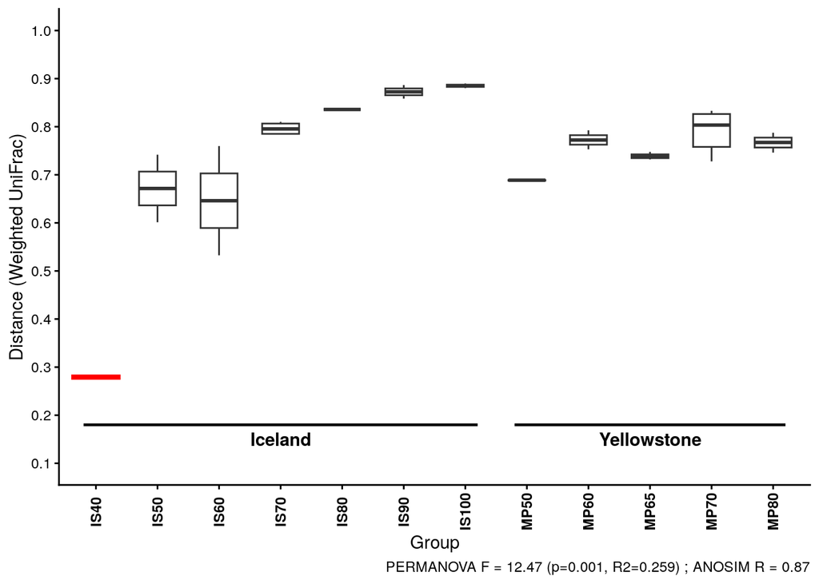

```
##
## --- RÉSULTATS STATISTIQUES COMPLETS (FIG 4) ---
## Permutation test for adonis under reduced model
## Terms added sequentially (first to last)
## Permutation: free
## Number of permutations: 999
##
## adonis2(formula = dist_obj ~ Temp_Num + Location, data = metadata)
##          Df SumOfSqs      R2       F Pr(>F)
## Temp_Num  1   1.8527 0.25916 12.4740  0.001 ***
## Location  1   0.8404 0.11756  5.6586  0.001 ***
## Residual 30   4.4557 0.62328
## Total    32   7.1488 1.00000
## ---
## Signif. codes:  0 '***' 0.001 '**' 0.01 '*' 0.05 '.' 0.1 ' ' 1
## ANOSIM R-statistic : 0.87
## ----------------------------------------------
```

```r
library(phyloseq)
library(ggplot2)
library(dplyr)
library(vegan)

if(!exists("ps_rel")){
  ps_rel <- transform_sample_counts(ps_rare, function(x) 100 * x / sum(x))
}

# --- 1. PRÉPARATION DES GROUPES ---
metadata <- data.frame(sample_data(ps_rare))
metadata$Temp_Num <- as.numeric(gsub(",", ".", as.character(metadata$Temp_Num)))

metadata <- metadata %>% mutate(Group = case_when(
  Location == "YNP" & abs(Temp_Num - 65.5) < 0.5 ~ "MP65",
  Location == "YNP" ~ paste0("MP", round(Temp_Num / 10) * 10),
  Location == "Iceland" ~ paste0("IS", round(Temp_Num / 10) * 10),
  TRUE ~ NA_character_
))

# --- 2. CALCUL DES DISTANCES ET STATISTIQUES ---
dist_obj <- phyloseq::distance(ps_rare, method = "wunifrac")
dist_matrix <- as.matrix(dist_obj)

# CALCUL RÉEL DES STATS (PERMANOVA + ANOSIM)
perm_test <- adonis2(dist_obj ~ Temp_Num + Location, data = metadata) # Modèle complet
vrai_f <- round(perm_test$F[1], 2)
vrai_p <- perm_test$`Pr(>F)`[1]
vrai_r2 <- round(perm_test$R2[1], 3)

# Calcul de l'ANOSIM (pour comparer au 0.77 des auteurs)
anosim_res <- anosim(dist_obj, metadata$Group)
vrai_r_anosim <- round(anosim_res$statistic, 2)

# Affichage des résultats dans la console (Home)
cat("\n--- RÉSULTATS STATISTIQUES COMPLETS (FIG 4) ---\n")
print(perm_test)
cat("ANOSIM R-statistic :", vrai_r_anosim, "\n")
cat("----------------------------------------------\n")

ref_samples <- rownames(metadata[metadata$Group == "IS40" & !is.na(metadata$Group), ])
metadata$Dist_to_IS40 <- rowMeans(dist_matrix[, ref_samples])
valeur_base_IS40 <- mean(metadata$Dist_to_IS40[metadata$Group == "IS40"], na.rm = TRUE)

# --- 3. RÉGLAGE DE L'ORDRE ---
target_order <- c("IS40", "IS50", "IS60", "IS70", "IS80", "IS90", "IS100",
                  "MP50", "MP60", "MP65", "MP70", "MP80")
metadata$Group <- factor(metadata$Group, levels = target_order)

# --- 4. GÉNÉRATION DU GRAPHIQUE ---
fig4_final <- ggplot(metadata, aes(x = Group, y = Dist_to_IS40)) +
  geom_boxplot(outlier.shape = NA, width = 0.6, lwd = 0.5) +

  annotate("segment", x = 0.6, xend = 1.4, y = valeur_base_IS40, yend = valeur_base_IS40,
           color = "red", size = 1.5) +

  scale_y_continuous(limits = c(min(0.1, valeur_base_IS40 - 0.05), 1.0),
                     breaks = seq(0, 1.0, 0.1)) +

  theme_classic() +
  theme(axis.text.x = element_text(angle = 90, vjust = 0.5, face = "bold"),
        panel.grid = element_blank()) +

  # Légende enrichie avec R2 et ANOSIM
  labs(y = "Distance (Weighted UniFrac)", x = "Group",
       caption = paste0("PERMANOVA F = ", vrai_f, " (p=", vrai_p, ", R2=", vrai_r2, ") ; ANOSIM R = ", vrai_r_anosim)) +

  annotate("text", x = 4, y = 0.15, label = "Iceland", fontface = "bold") +
  annotate("text", x = 10, y = 0.15, label = "Yellowstone", fontface = "bold") +
  annotate("segment", x = 0.8, xend = 7.2, y = 0.18, yend = 0.18, size = 0.8) +
  annotate("segment", x = 7.8, xend = 12.2, y = 0.18, yend = 0.18, size = 0.8)

# --- 5. EXPORTATION ---
ggsave("~/Figure4_Final_AutoRef.png", plot = fig4_final, width = 9, height = 6, dpi = 300)

# Affichage
fig4_final
```

FIGURE 4 | Weighted UniFrac location-temperature group significance plot. Distances are relative to the lowest temperature group (Flúðir Hverahólmi, Iceland, 40◦C). IS, Iceland. MP, Mirror Pool

Commentaire :

On observe des tendances assez similaires par rapport à ce qui avait été trouvé dans l’article. La réalisation du test PERMANOVA confirme que la température est le moteur principal de la structure des communautés avec un pseudo-F de 12,47 (p=0,001) et un R2 de 0,259. Ce résultat est complété par un test ANOSIM affichant un R de 0,87, ce qui souligne une séparation très nette des groupes selon le gradient thermique, dépassant même la valeur de 0,77 rapportée par Podar et al. Cependant, les valeurs de distances sont différentes : elles sont globalement plus élevées que dans l’article. Ces différences peuvent être expliquées par l’utilisation d’outils et de démarches différentes entre l’article et notre analyse, notamment l’utilisation de DADA2 pour l’inférence des ASVs. Malgré ces écarts de valeurs, l’augmentation progressive de la distance avec la chaleur valide l’idée que le gradient thermique impose une restructuration taxonomique universelle, ce qui s’affranchit des distances biogéographiques entre l’Islande et Yellowstone.

```r
library(ggplot2)
library(dplyr)
library(stringr)

# --- 1. PRÉPARATION DES DONNÉES ---
df_final <- psmelt(ps_rel) %>%
  filter(!is.na(Phylum), Phylum != "NA", !is.na(Kingdom), Kingdom != "NA") %>%
  mutate(
    Kingdom = toupper(Kingdom),
    Source = case_when(
      str_detect(Dim, "^MP") ~ "Mirror Pool, YNP",
      str_detect(Dim, "^FL") ~ "Flúðir, Iceland",
      str_detect(Dim, "^HD") ~ "Hurðarbak, Iceland",
      TRUE ~ "Sites"
    ),
    Temp_Num = as.numeric(str_extract(Dim, "\\d+"))
  )

# Force l'ordre des sites
df_final$Source <- factor(
  df_final$Source,
  levels = c("Mirror Pool, YNP", "Flúðir, Iceland", "Hurðarbak, Iceland")
)

# Tri des échantillons
df_final$Dim <- factor(
  df_final$Dim,
  levels = unique(df_final$Dim[order(df_final$Source, df_final$Temp_Num)])
)

# Tri taxonomique
phylum_ordre <- df_final %>%
  distinct(Kingdom, Phylum) %>%
  arrange(Kingdom, Phylum) %>%
  mutate(ord = rev(row_number())) %>%
  arrange(ord) %>%
  pull(Phylum)

df_final$Phylum <- factor(df_final$Phylum, levels = phylum_ordre)

# --- 2. CRÉATION DU GRAPHIQUE ---
p <- ggplot(df_final, aes(x = Dim, y = Phylum)) +
  geom_point(aes(size = Abundance), color = "black") +
  scale_size_area(
    name = "Abundance (%)",
    breaks = c(4, 8, 16, 32, 64),
    labels = c("4", "8", "16", "32", "64 %"),
    max_size = 6
  ) +
  facet_grid(Kingdom ~ Source, scales = "free", space = "free", switch = "y") +
  scale_x_discrete(position = "top") +
  theme_bw() +
  theme(
    panel.spacing = unit(0.1, "lines"),
    strip.background = element_blank(),
    strip.text = element_text(face = "bold", size = 10),
    strip.placement = "outside",
    axis.text.x = element_text(angle = 45, hjust = 0, size = 9, color = "black"),
    axis.text.y = element_text(size = 9, face = "italic", color = "black"),
    axis.title = element_blank(),
    panel.grid.major = element_line(color = "grey95", linewidth = 0.1),
    panel.border = element_rect(color = "black", fill = NA, linewidth = 0.5),
    legend.position = "bottom",
    plot.margin = margin(t = 5, r = 5, b = 5, l = 25, unit = "mm")
  ) +
  guides(size = guide_legend(nrow = 1, label.position = "bottom"))

# --- 3. EXPORTATION ET AFFICHAGE UNIQUE ---

ggsave("~/Figure5_Correct_Order.png", plot = p, width = 21, height = 29.7, units = "cm", dpi = 300, bg = "white")

p
```

[figure not shown]

FIGURE 5 | Microbial diversity (phylum level) at the three thermal springs depending on general temperature (40–100◦C). Circle size indicates the inferred relative abundance, based on amplicon data (in %).

```r
library(phyloseq)
library(ggplot2)
library(dplyr)
library(stringr)

# --- 1. PRÉPARATION (AGRÉGATION AU GENRE) ---
ps_genus <- tax_glom(ps, taxrank = "Genus")
ps_rel_genus <- transform_sample_counts(ps_genus, function(x) 100 * x / sum(x))

# --- 2. TRAITEMENT DES DONNÉES (GENRE OU FAMILLE) ---
df_fig6 <- psmelt(ps_rel_genus) %>%
  filter(Abundance > 1) %>%
  filter(!is.na(Family), Family != "NA") %>%
  mutate(
    Taxon_Name = if_else(is.na(Genus) | Genus == "NA" | Genus == "",
                         paste0(Family, " (f.)"),
                         as.character(Genus)),

    Taxa_Label = paste(Phylum, Taxon_Name, sep = " "),

    Kingdom = toupper(Kingdom),
    Source = factor(case_when(
      str_detect(Dim, "^MP") ~ "Mirror Pool, YNP",
      str_detect(Dim, "^FL") ~ "Flúðir, Iceland",
      str_detect(Dim, "^HD") ~ "Hurðarbak, Iceland"
    ), levels = c("Mirror Pool, YNP", "Flúðir, Iceland", "Hurðarbak, Iceland")),
    Temp_Num = as.numeric(str_extract(Dim, "\\d+"))
  )

# --- 3. GESTION DES ORDRES ---
df_fig6$Dim <- factor(df_fig6$Dim,
                      levels = unique(df_fig6$Dim[order(df_fig6$Source, df_fig6$Temp_Num)]))

ordre_taxo_6 <- df_fig6 %>%
  distinct(Kingdom, Phylum, Taxon_Name, Taxa_Label) %>%
  arrange(Kingdom, Phylum, Taxon_Name) %>%
  mutate(ord = rev(row_number())) %>%
  arrange(ord) %>%
  pull(Taxa_Label)

df_fig6$Taxa_Label <- factor(df_fig6$Taxa_Label, levels = ordre_taxo_6)

# --- 4. CRÉATION DU GRAPHIQUE ---
p6 <- ggplot(df_fig6, aes(x = Dim, y = Taxa_Label)) +
  geom_point(aes(size = Abundance), color = "black") +
  scale_size_area(name = "Relative abundance (%)",
                  breaks = c(4, 8, 16, 32, 64),
                  labels = c("4", "8", "16", "32", "64 %"),
                  max_size = 6) +
  facet_grid(. ~ Source, scales = "free", space = "free") +
  scale_x_discrete(position = "top") +
  theme_bw() +
  theme(
    strip.background = element_blank(),
    strip.text = element_text(face = "bold", size = 10),
    axis.text.x = element_text(angle = 45, hjust = 0, size = 8, color = "black"),
    axis.text.y = element_text(size = 7, face = "italic", color = "black"),
    axis.title = element_blank(),
    panel.grid.major = element_line(color = "grey95", linewidth = 0.1),
    legend.position = "bottom",
    plot.margin = margin(5, 5, 5, 5, "mm")
  ) +
  guides(size = guide_legend(nrow = 1, label.position = "bottom"))

# --- 5. EXPORTS ET AFFICHAGE UNIQUE ---
ggsave("~/Figure6_Genera_Families_Final.png", plot = p6,
       width = 21, height = 35, units = "cm", dpi = 300, bg = "white")

p6
```

[figure not shown]

FIGURE 6 | Most abundant genera/families at the three thermal springs depending on general temperature. Circle size indicates the inferred relative abundance based on amplicon data (in %).

Commentaires sur les figures 5 et 6 :

Enfin, les Figures 5 et 6 :

À basse température (~38°C), les mats microbiens sont dominés par des bactéries mésophiles et des Cyanobacteria. Entre 50 et 80°C, on observe des phototrophes et des thermophiles modérés, avec des différences entre Yellowstone et Islande, par exemple dans les Cyanobacteria et Chloroflexi. Enfin, au delà de 70°C, les mats microbiens disparaissent et les communautés sont dominées par des Archaea et des thermophiles extrêmes comme Pyrobaculum et Thermocrinis : dans l’article, ils parlent de Pyrobaculum et Ignisphaera, il y a donc une différence dont une des raisons peut être la raréfaction de départ (Ignisphaera aurait pu être présente qu’en faible quantité et n’aurait pas été “piochée.”). On a donc ici beaucoup d’observations similaires à l’article initial. Ainsi, ces deux figures montrent que la température crée des niches très distinctes, structurant fortement la composition des communautés.

```r
library(Biostrings)

# Calcul de l'abondance totale par ASV
abundance <- colSums(seqtab.nochim)

prepare_fasta_figure7_with_abundance <- function(search_term, file_name, n_asv = 5) {

  # 1. Identification des ASVs du groupe
  matches <- apply(taxa, 1, function(x) any(grepl(search_term, x, ignore.case = TRUE)))
  group_asvs <- rownames(taxa)[which(matches)]

  if(length(group_asvs) == 0) {
    message("⚠️ Aucun ASV trouvé pour : ", search_term)
    return(NULL)
  }

  # 2. Sélection des n ASVs les plus abondants au TOTAL
  top_asvs <- names(sort(abundance[group_asvs], decreasing = TRUE)[1:min(n_asv, length(group_asvs))])
  top_asvs <- na.omit(top_asvs)

  # 3. Détermination de l'origine géographique
  srr_iceland <- rownames(metadata)[metadata$Location == "Iceland"]
  srr_ynp <- rownames(metadata)[metadata$Location == "YNP"]

  labels <- sapply(top_asvs, function(asv) {
    sum_ice <- sum(seqtab.nochim[srr_iceland, asv])
    sum_ynp <- sum(seqtab.nochim[srr_ynp, asv])
    if(sum_ice > sum_ynp) return("Iceland") else return("Yellowstone")
  })

  # 4. Création des séquences avec Abondance dans le nom
  # Format : Origine_Groupe_Abondance
  final_seqs <- DNAStringSet(as.character(top_asvs))

  # On utilise format(..., big.mark=",") pour avoir les séparateurs de milliers comme dans l'article
  names(final_seqs) <- paste0(labels, "_", search_term, "_", format(abundance[top_asvs], big.mark=","))

  # 5. Exportation vers le HOME (~/)
  writeXStringSet(final_seqs, file.path("~", file_name))
  message("✅ Fichier créé avec abondances : ", file_name)
}

# --- LANCEMENT POUR LES 4 GROUPES ---
prepare_fasta_figure7_with_abundance("Geoarchaeales", "Fig7_Archaea.fasta")
prepare_fasta_figure7_with_abundance("Thermoflexus", "Fig7_Thermoflexus.fasta")
prepare_fasta_figure7_with_abundance("Roseiflexus", "Fig7_Roseiflexus.fasta")
prepare_fasta_figure7_with_abundance("Cyanobacteria", "Fig7_Cyanobacteria.fasta")
```

Figure 7.1, sans bootstrap :

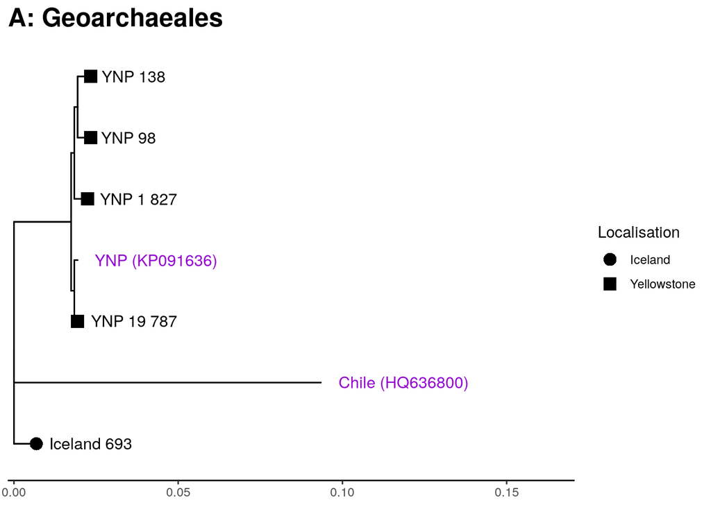

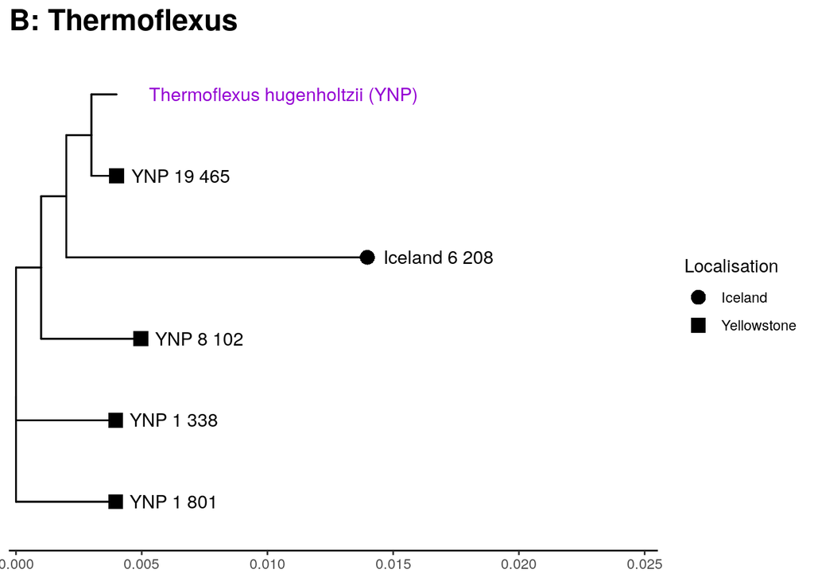

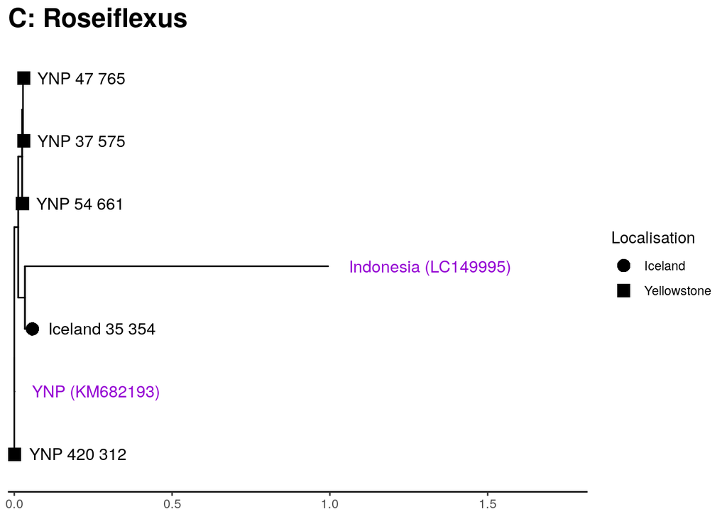

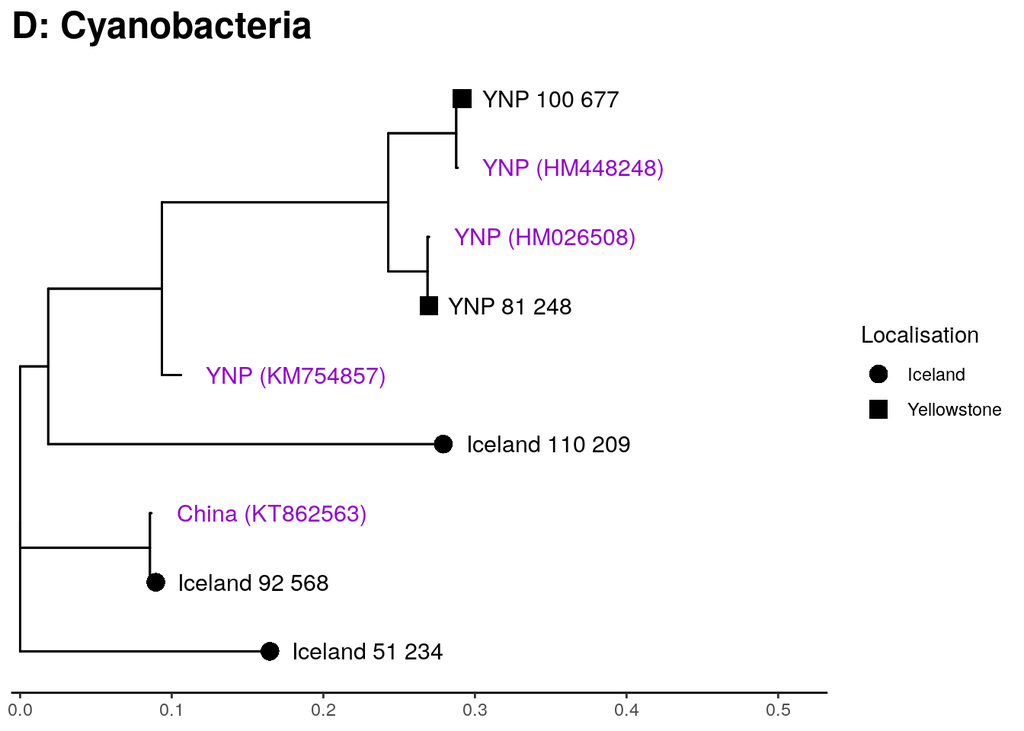

```r
library(treeio)
library(ggtree)
library(ggplot2)
library(dplyr)
library(stringr)

home_dir <- Sys.getenv("HOME")
input_nhx <- c("Arbre_1.nhx", "Arbre_2.nhx", "Arbre_3.nhx", "Arbre_4.nhx")
titles <- c("A: Geoarchaeales", "B: Thermoflexus", "C: Roseiflexus", "D: Cyanobacteria")

for (i in 1:length(input_nhx)) {
  file_path <- file.path(home_dir, input_nhx[i])
  if (!file.exists(file_path)) next

  tr <- read.nhx(file_path)

  # 1. RÉGLAGE ÉCHELLE
  tr@phylo$edge.length[tr@phylo$edge.length < 0.001] <- 0.001

  plot_df <- fortify(tr)

  # 2. NETTOYAGE DES LABELS
  plot_df <- plot_df %>%
    mutate(
      label = as.character(label),
      label_clean = label %>%
        str_replace_all("_", " ") %>%
        str_replace_all(", ", " ") %>%
        str_replace_all(" ,", " ") %>%
        str_squish(),

      # 3. PARENTHÈSES
      label_clean = str_replace(label_clean, "\\b([A-Z]{2}[0-9]{5,6})\\b", "(\\1)"),

      # 4. THERMOFLEXUS
      label_clean = ifelse(grepl("hugenholtzii", label_clean, ignore.case = TRUE),
                           paste(label_clean, "(YNP)"),
                           label_clean),

      # 5. COULEURS ET FORMES
      is_ref = grepl("\\(|Chile|China|Japan|Indonesia|Norway|hugenholtzii", label_clean, ignore.case = TRUE),
      node_color = ifelse(is_ref, "darkviolet", "black"),
      Loc = case_when(
        !is_ref & grepl("Iceland", label) ~ "Iceland",
        !is_ref & grepl("YNP|Yellowstone", label) ~ "Yellowstone",
        TRUE ~ NA_character_
      )
    )

  # 6. DESSIN
  max_tree_x <- max(plot_df$x, na.rm = TRUE)

  p <- ggtree(tr) %<+% plot_df +
    geom_tree() +
    geom_tippoint(aes(subset = !is.na(Loc), shape = Loc), size = 4, na.rm = TRUE) +
    geom_tiplab(aes(label = label_clean, color = I(node_color)),
                size = 4, offset = max_tree_x * 0.01, hjust = -0.1) +

    scale_shape_manual(values = c("Iceland" = 16, "Yellowstone" = 15),
                       name = "Localisation", na.translate = FALSE) +

    scale_x_continuous(expand = expansion(mult = c(0.02, 0.8))) +

    ggtitle(titles[i]) +
    theme_tree2() +
    theme(legend.position = "right",
          panel.grid = element_blank(),
          plot.title = element_text(size = 18, face = "bold"))

  # 7. SAUVEGARDE (DANS LE HOME)
  ggsave(filename = file.path(home_dir, paste0("Arbre_Synthese_Final_", i, ".png")),
         plot = p, width = 16, height = 9, dpi = 300)

  # --- 8. AFFICHAGE (DANS LE NOTEBOOK) ---
  # Cette commande force l'affichage de chaque arbre lors du passage dans la boucle
  print(p)
}
```

Figure 7.2, avec bootstrap :

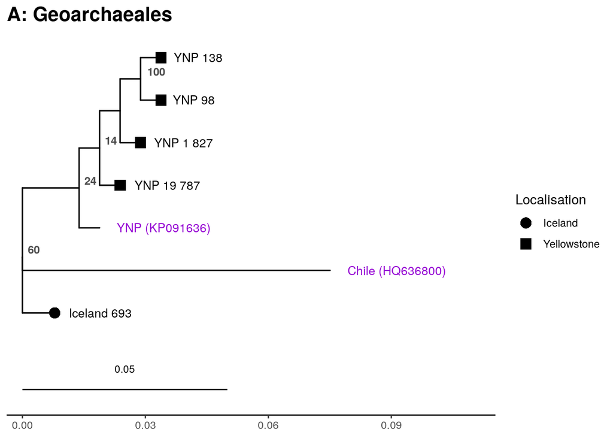

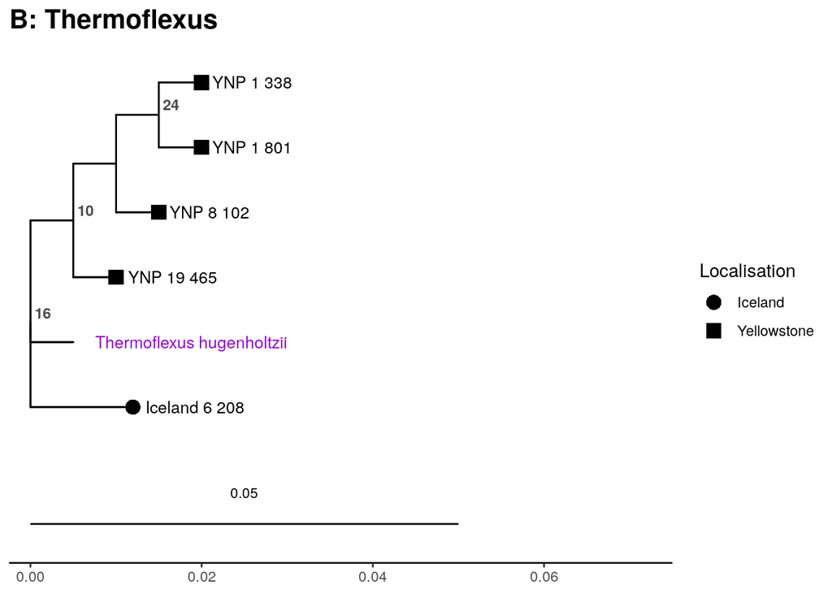

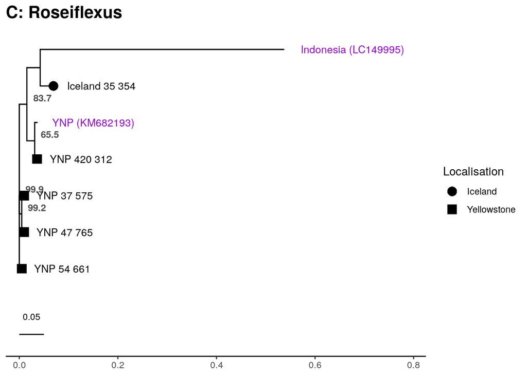

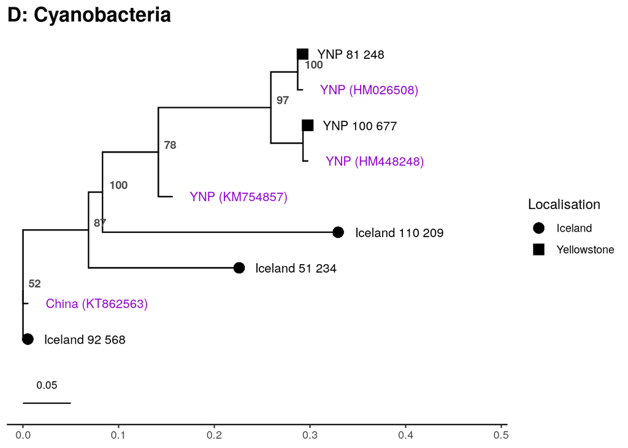

```r
library(treeio)
library(ggtree)
library(ggplot2)
library(dplyr)
library(stringr)

home_dir <- Sys.getenv("HOME")
input_nhx <- c("BArbre_1.nhx", "BArbre_2.nhx", "BArbre_3.nhx", "BArbre_4.nhx")
titles <- c("A: Geoarchaeales", "B: Thermoflexus", "C: Roseiflexus", "D: Cyanobacteria")

for (i in 1:length(input_nhx)) {
  file_path <- file.path(home_dir, input_nhx[i])
  if (!file.exists(file_path)) next

  tr <- read.nhx(file_path)
  plot_df <- fortify(tr)

  # --- 1. DÉTECTION ET HARMONISATION DU BOOTSTRAP ---
  cols_to_check <- setdiff(colnames(plot_df), c("parent", "node", "branch.length", "x", "y", "isTip", "branch", "angle"))
  plot_df$display_bootstrap <- NA_character_

  for(col in cols_to_check) {
    vals <- as.numeric(as.character(plot_df[[col]][!plot_df$isTip]))
    if(any(!is.na(vals) & vals != "")) {
      plot_df$display_bootstrap <- ifelse(!plot_df$isTip & !is.na(vals),
                                          ifelse(vals <= 1, round(vals * 100, 1), round(vals, 0)),
                                          NA_character_)
      break
    }
  }

  # --- 2. NETTOYAGE DES NOMS ---
  plot_df <- plot_df %>%
    mutate(
      label_clean = as.character(label) %>%
        str_replace_all("-", " ") %>%
        str_replace_all("_+", " ") %>%
        str_trim(),
      label_clean = str_replace(label_clean, "([A-Z]{2}[0-9]{5,6})", "(\\1)"),
      is_ref = grepl("\\(|Chile|China|Japan|Indonesia|Norway|hugenholtzii", label_clean, ignore.case = TRUE),
      node_color = ifelse(is_ref, "darkviolet", "black"),
      Loc = case_when(
        !is_ref & grepl("Iceland", label) ~ "Iceland",
        !is_ref & grepl("YNP|Yellowstone", label) ~ "Yellowstone",
        TRUE ~ NA_character_
      )
    )

  # --- 3. CONSTRUCTION DU GRAPHIQUE ---
  # On augmente légèrement la longueur minimale pour décoller les nœuds du bord
  tr@phylo$edge.length[tr@phylo$edge.length < 0.005] <- 0.005
  max_x <- max(plot_df$x, na.rm = TRUE)

  p <- ggtree(tr) %<+% plot_df +
    geom_tree() +

    # --- AJUSTEMENT ICI : nudge_x déplace les valeurs vers la droite ---
    geom_text(aes(label = display_bootstrap, x = x, y = y),
              vjust = -0.4,
              hjust = -0.2,   # Déplacement horizontal
              nudge_x = max_x * 0.01, # Petit décalage proportionnel
              size = 3.2,
              color = "grey30",
              fontface = "bold", # Gras pour plus de lisibilité
              na.rm = TRUE,
              data = td_filter(!isTip & !is.na(display_bootstrap) & display_bootstrap != "")) +

    geom_treescale(x = 0, y = -0.8, width = 0.05, fontsize = 3) +
    geom_tippoint(aes(subset = !is.na(Loc), shape = Loc), size = 4, na.rm = TRUE) +

    geom_tiplab(aes(label = label_clean, color = I(node_color)),
                size = 3.5, offset = max_x * 0.02, hjust = -0.1) +

    scale_shape_manual(values = c("Iceland" = 16, "Yellowstone" = 15),
                       name = "Localisation", na.translate = FALSE) +
    scale_x_continuous(expand = expansion(mult = c(0.05, 0.5))) + # Marge à gauche augmentée

    ggtitle(titles[i]) +
    theme_tree2() +
    theme(legend.position = "right",
          panel.grid = element_blank(),
          plot.title = element_text(size = 16, face = "bold"))

  # --- 4. SAUVEGARDE ET AFFICHAGE ---
  ggsave(filename = file.path(home_dir, paste0("Arbre_Lisible_", i, ".png")),
         plot = p, width = 14, height = 8, dpi = 300)

  print(p)
}
```

Les arbres ont été réalisé en suivant ces étapes :

1. Réunir dans des fichiers séparés les ASVs les plus abondants (cinqs) correspondant aux Geoarchaeale, aux Thermoflexus, aux Roseiflexus et aux Cyanobacteria.
2. Réaliser des alignements de ces ASVs en dehors de R en utilisant l’outil MAFFT (Online Service).
3. Construction des données des arbres en utilisant la méthode Neighbor-Joining avec la correction JC69 (NGPhylogeny.fr)
4. Construction des arbres depuis R.

Autre étape : génération des arbres avec boostrap (grâce à NGPhylogeny.fr aussi) de manière à part. Les arbres avec ou sans boostrap ont été réalisés.

Commentaire :

Egalement pour cette figure, nous obtenons ici des patrons similaires à ce qui avait été obtenu par les auteurs de l’étude. Les différences de structures entre les arbres avec et sans boostrap peuvent s’expliquer par l’utilisation de workflows différents sur la plateforme NGPhylogeny puisque pour certains arbres, le workflow par défaut générait un message d’erreur pour la création des arbres avecc boostrap : ainsi, les données ont pu être traitées différemment car j’ai ajusté les paramètres. Nos arbres présentent plus de séquences que les auteurs, afin de mieux représenter la microdiversité.

Aussi, on observe :

- Pour les Archaea, Geoarchaeales : On observe des tendances assez similaires par rapport à ce qui avait été trouvé dans l’article pour ce groupe. En effet, pour les Geoarchaeales, l’arbre montre une séparation géographique très nette : les échantillons d’Islande (cercles) et ceux de Yellowstone (carrés) sont sur des branches séparées. Ça confirme l’idée d’endémisme de l’article : même si la température est la même, l’isolement géographique a fait diverger les populations. Comme l’explique l’article, seulement 7 % des ASVs sont communs aux deux sites, et on le voit bien ici puisque les séquences ne se mélangent pas entre les deux régions. Cela soutient l’hypothèse que ces lignées évoluent chacune de manière à part, ce qui génère des espèces ou sous-espèces propres à chaque zone géothermique.
- Pour les Chloroflexi, Thermoflexus : l’arbre que nous avons obtenu montre un résultat intéressant par rapport à la figure 7 de l’article. En effet, on remarque que la séquence de référence Thermoflexus hugenholtzii (YNP) est à la fois proche d’un échantillon d’Islande et de plusieurs échantillons du parc de Yellowstone. C’est un point qui vient nuancer l’hypothèse d’endémisme total, car cette référence semble ici faire un lien entre les deux régions biogéographiques. Cependant, malgré cette proximité avec la référence, les échantillons d’Islande et de Yellowstone restent regroupés sur des branches séparées. Ainsi, sur ce point, cela rejoint ce que dit l’article : même si les lignées semblent apparentées, l’isolement géographique a quand même créé une divergence. On ne retrouve pas exactement les mêmes séquences d’un continent à l’autre, ce qui soutient l’idée que ces populations évoluent chacune de leur côté dans leurs zones géothermiques qui leur sont propres.
- Pour les Chloroflexi, Roseiflexus : l’arbre montre un résultat également en lien avec la figure 7 de l’article et soutient ici encore l’idée d’endémisme local. En effet, on remarque que l’échantillon d’Islande est situé sur une branche isolée, tandis que les échantillons de Yellowstone se positionnent ensemble sur un autre clade. Ici, les séquences de référence (en violet) montrent un fait intéressant : l’ASV d’Islande est plus proche d’une référence provenant d’Indonésie que de n’importe quel échantillon de Yellowstone alors que les ASVs de Yellowstone se regroupent avec une référence locale du parc. Cela confirme bien ce que souligne l’article : les populations divergent de manière si importante à cause de la distance que les lignées d’un site (Islande) peuvent être génétiquement plus éloignées de l’autre site étudié (Yellowtone) que de différentes références mondiales pourtant elles-mêmes très distantes.
- Pour les Cyanobacteria, unclultured : l’arbre montre ici encore une divergence géographique qui complète les observations précédentes. L’apport des séquences de référence est ici également important. En effet, tandis que les séquences de Yellowstone sont proches des séquences de référence locales, l’échantillon d’Islande se place à proximité d’une référence provenant de Chine.

IV-Conclusion :

Le but de notre analyse via le pipeline DADA2 était de voir si elle conduirait à des résultats similaires à ceux obtenus par les auteurs. C’est le cas puisque, à travers la reproduction des figures et des tests statistiques nous avont obtenus des tendances comparables. Les différences existantes peuvent être expliquées par l’utilisation d’outils différents. Ainsi, notre analyse montre, comme pour l’article de Podar et al. que la température influence la diversité alpha microbienne, que la température et la biogéographie ont un effet sur la diversité béta et qu’il y a une réduction non-linéaire du nombre de taxa quand les températures augmentent de 38°C à la température d’ébullition. Aussi, aux rangs taxonomiques élevés, les communautés microbiennes semblent bien être similaires entre les sources hydrothermales de Yellowstone et d’Islande, même si, au niveau du genre, il est toutefois observé un potentiel endémisme (en particulier en ce qui concerne les phototrophes thermophiles) : ils seraient peut-être davantage influencés par les paramètres physico-chimiques de chaques sites et par leur limite/capacité de dispersion.